# Red Booleana

## Genera una red de regulacíon transripcional con 5 nodos y, al menos, 7 interacciones regulatorias, escoge al menos 3 inhibiciones)

Lo primero que haremos será instalar nuestras librerias y llamarlas:

```r
library(BoolNet)
library(igraph)
```

A continuación generamos un archivo de texto con las reglas de operadores booleanos y lo cargamos a r con el siguiente código

```r
#La funcion loadNetwork nos permite convertir un archivo de texto a una red booleana

reg_tran<-loadNetwork("Rodriguez_Perla_T3_P2/RED.txt")
```

Imprimimos nuestra red para poder visualizarla

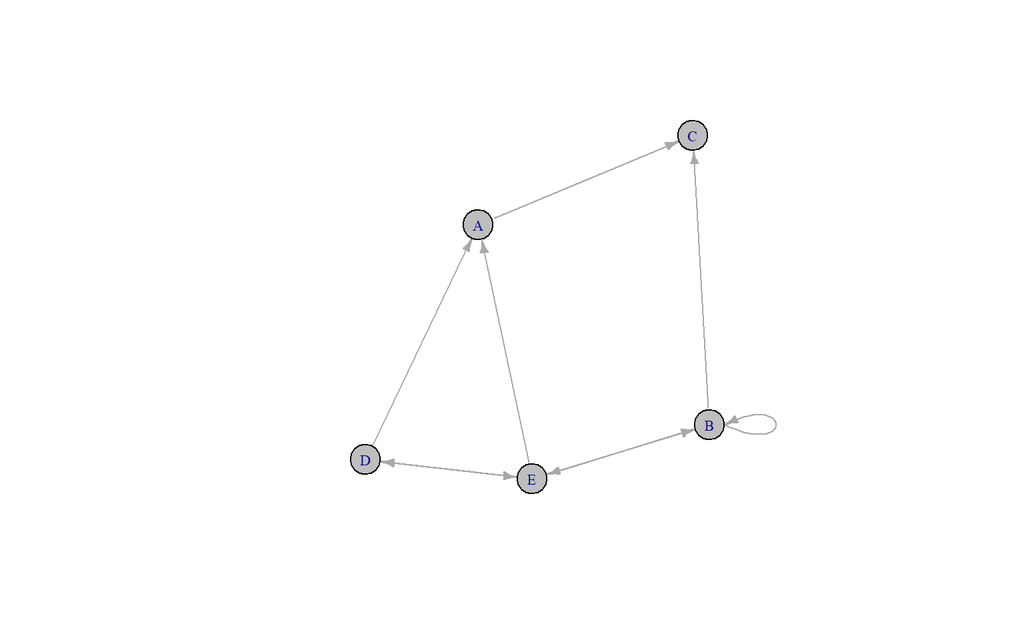

```r
plotNetworkWiring(reg_tran)
```

### Escribe las reglas para generar una red de tipo Boolnet. Con el siguiente código podemos cargar nuestras reglas de manera automática y visualiarlas en R

```r
tabla_verdad<-truthTableToSymbolic(reg_tran)
print(tabla_verdad)
```

```
## Symbolic representation of a Boolean network
##
## Transition functions:
## A = (E & !D)
## B = (B | !E)
## C = (B & A)
## D = E
## E = (B | D)
```

### Encuentra todos los atractores de tu red

Con la función **getAttractors** identiicamos los atractores de nuestra red y sus cuencas de atracción.

```r
atractores<- getAttractors(reg_tran)
atractores
```

```
## Attractor 1 is a simple attractor consisting of 1 state(s) and has a basin of 28 state(s):
##
##  |--<----|
##  V       |
##  01011   |
##  V       |
##  |-->----|
##
##
## Genes are encoded in the following order: A B C D E
##
## Attractor 2 is a simple attractor consisting of 1 state(s) and has a basin of 4 state(s):
##
##  |--<----|
##  V       |
##  00011   |
##  V       |
##  |-->----|
##
##
## Genes are encoded in the following order: A B C D E
```

Como podemos observar en el resultado anterior, teneos 2 atractores, el atractor 1 se compone de una cuenca de 28 estados y el atractor 2 se compone de una cuenca de 4 estados.

Si utilizamos el siguiente código podemos visualizar graficamente los estados de nuestros genes en nuestros atractores, el rojo indica que nuestros genes estan apagados y el verde que los genes están encendidos.

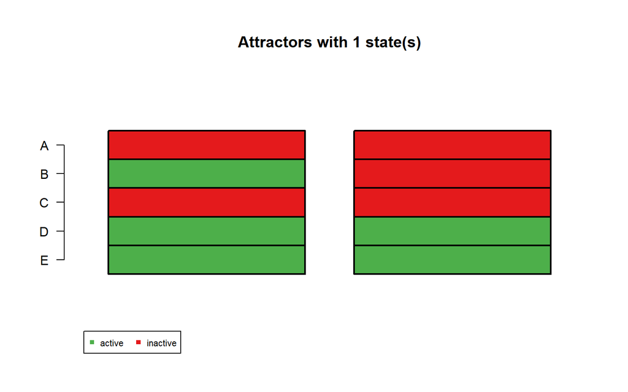

```
## $`1`
##   Attr1.1 Attr2.1
## A       0       0
## B       1       0
## C       0       0
## D       1       1
## E       1       1
```

```r
plotAttractors(atractores)
```

### ¿Cuál serıa el estado final m ́as probable

Una cuenca de atraccion s define como los estados que conducen a este atractor, en nuestro caso tenemos 2 atractores, el *ATRACTOR 1* compuesto por 28 estados y el *ATRACTOR2* compuesto por 4 estados, lo que indica que nuestro atractor 1 tiene una fuerza más grande de atracción y la probabilidad de caer en él es mayor que la de caer en el atractor 2, por lo que nuestro estado más probable sería el *ATRACTOR1*: 01011 en orden ABCDE,considerando al 1 como encendido y el 0 como apagado.

Lo anterior lo podemos comprobar con la siguiente funcion:

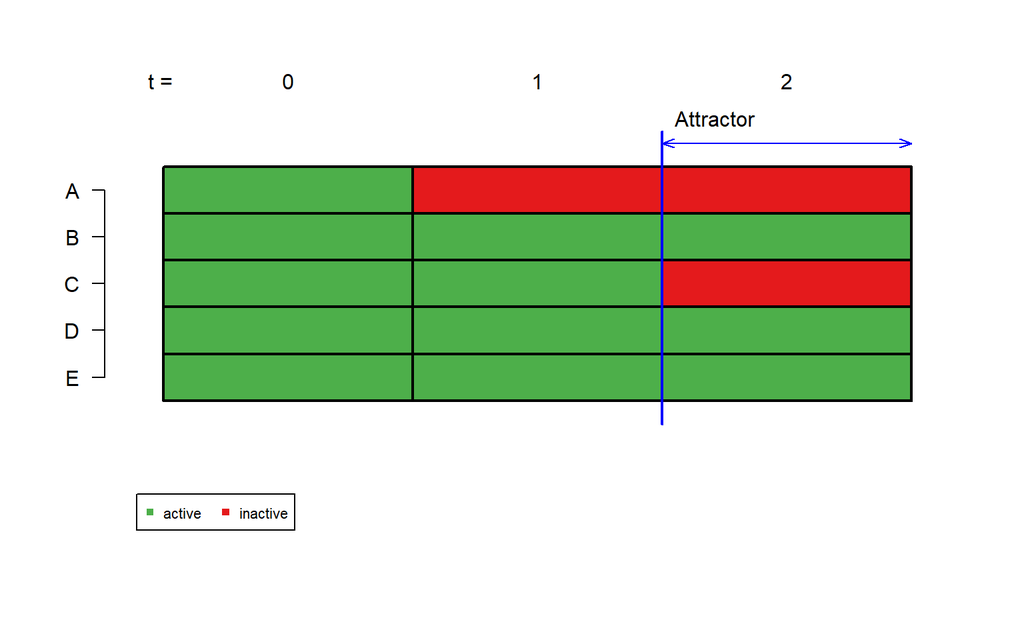

```
##   1 2 3
## E 1 1 1
## D 1 1 1
## C 1 1 0
## B 1 1 1
## A 1 0 0
```

```r
plotSequence(network=reg_tran,
             startState=rep(1,5),
             includeAttractorStates="all")
```

Se observa la visualizacion de los estados dado una condicion inicial (t=0), donde todos los genes estan encendidos, en el t=1, se apaga el gen A y en el t=2, nuestra red cae en el *ATRACTOR1* (01011).

### Dibuja todos los estados y sus atractores

El siguiente código nos muestra todos nuestros posibles estados, el estado siguiente y el atractor en el que caeran

```r
print(getTransitionTable(atractores))
```

```
##   State     Next state  Attr. basin  # trans. to attr.
##   00000 =>       01000            1                  5
##   10000 =>       01000            1                  5
##   01000 =>       01001            1                  4
##   11000 =>       01101            1                  4
##   00100 =>       01000            1                  5
##   10100 =>       01000            1                  5
##   01100 =>       01001            1                  4
##   11100 =>       01101            1                  4
##   00010 =>       01001            1                  4
##   10010 =>       01001            1                  4
##   01010 =>       01001            1                  4
##   11010 =>       01101            1                  4
##   00110 =>       01001            1                  4
##   10110 =>       01001            1                  4
```

[output cut: 20 more lines]

Y con este comando podemos visualizar los atractores de nuestra red de manera gráfica

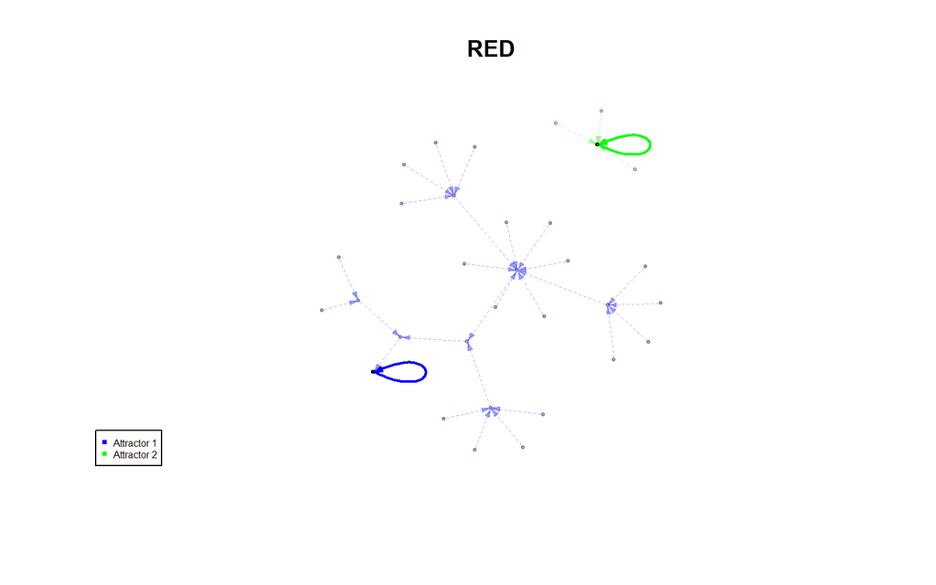

```r
plotStateGraph(atractores, main = "RED", layout = layout.fruchterman.reingold)
```